# Capstone Project - The Battle of the Neighborhoods

# Toronto Canada

[figure not shown]

## Applied Data Science Capstone by IBM/Coursera ---- Valeriu Badea

### --Text

- Introduction: Business Problem
- Data
- Methodology
- Results
- Discussion
- Conclusion

## Introduction: Business Problem

Some investors from my native country, Romania asked me to analyze the investment possibilities in Toronto, Canada. The project can be also used by Toronto visitors, people who want to relocate in Toronto and investors interested in another kind of business Anyway their first preference is a traditional Romanian restaurant. The business requirements are large and the most important information come from financial data of the similar businesses around the chosen location. How many clients, how much they spend, what is the preferred menu are questions which will be analyzed in the followings studies. This initial project is going to respond to general problems like:

1. Position (how many similar businesses are around, landscape, parking, local traffic, etc.
   - Proximity to other businesses. Neighboring businesses may influence your store's sales, and their presence can work for you or against you.
   - Customer parking facilities. The site should provide convenient, adequate parking as well as easy access for customers.
   - Accessibility. Consider how easy it will be for customers to reach into your business. If you are mostly considering pedestrian traffic, consider whether or not nearby businesses will generate foot traffic for you.
   - The rent-paying capacity. If you have done a sales-and-profit projection for your first year of operation, you will know approximately how much revenue you can expect to generate, and you can use that information to decide how much rent you can afford to pay.
   - Traffic density. you have to check for food traffic, and to approximate sales potential of each pedestrian passing a given location. Two factors are very important: total pedestrian traffic during business hours and the percentage of it that is likely to patronize your food service business.
   - History of the site. Take out the recent history of each site into consideration before you make a final selection. Who were the previous tenants, and why are they no longer there?
   - Anticipated sales volume. Can the location contribute to your sales volume? Consider how easy it will be for customers to get into your business.
2. Demographic (nationality, income, age, etc.). Age is very important if you consider a restaurant business.
   - Generation Y (born between 1965 and 1980) is the most ethnically diverse generation yet and is more than three times the size of generation X. They are a prime target for a food-service business. About 25 percent of their restaurant visits are to burger franchises, follow by pizza restaurants at 12 percent.
   - Baby boomers. (born between 1946 and 1964) They represent a group of affluent professionals who can afford to visit upscale restaurants and spend money freely. During the 1980s, they were the main customer group for upscale, trendy restaurants. Today, those on the leading edge of the boomer generation are becoming grandparents, making them best customers for restaurants that offer a family-friendly atmosphere and those that provide an upscale, formal dining experience.
   - Seniors age 65 and older. Generally, on fixed incomes and may not often be able to afford upscale restaurants. They like to visit family-style restaurants that offer good service and reasonable prices. "Younger" seniors are likely to be more active and have more disposable income than "older" seniors, whose health may be declining. Seniors typically appreciate restaurants that offer early-bird specials and senior menus with lower prices and smaller portions, since their appetites are less hearty than those of younger people.

Go on top

## Data

- After understanding the business I started an extensive search process for the most suitable data.
- The data have been clear out from nonimportant information. Useful tables have been copied and meaningful information has been stored in pandas dataframes which could be visualized and analyzed
- The main idea is to use foursquare to find out the venues around some centroids,and after that to analyze the best opportunity to place a business,in our case a restaurant.
- In order to do this a grid of equidistance centroids should be created to cover the whole city and its borrows.
- In Toronto case this isn't necessary because only a part of Postal offices cover the whole city.
- A subroutine in my code shows that the distances between any different postal offices locations is less than 700 m, so the whole city can be covered by just a group of postal office location using a search radius of 500 m.
- I am happy about this discovery because I can use some work already done. Thank’ s
- Information from ‘Demographics_of_Toronto_neighbourhoods' help me to create comparations between Toronto neighborhoods pertinent to establishment of a new business

#### I found the following useful data:

- List of postal codes of Toronto Canada from Wikipedia 'http://en.wikipedia.org/wiki/List_of_postal_codes_of_Canada:_M'
- IBM file 'http://cocl.us/Geospatial_data'
- Foursquare API
- Latitude/Longitude Distance Calculator 'https://www.nhc.noaa.gov/gccalc.shtml'
- Demographics of Toronto Neighbourhoods from Wikipedia 'https://en.wikipedia.org/wiki/Demographics_of_Toronto_neighbourhoods'

Go on top

```python
# Use folium to generate a map of Toronto, Canada with postal codes included

map_Toronto = folium.Map(location =[latitude,longitude], zoom_start =10)

for lat, lng, postal_code  in zip( df1['Latitude'], df1['Longitude'], df1['Postal Code']):
    label = '{}'.format(postal_code)
    label = folium.Popup(label, parse_html= True)
    folium.CircleMarker([lat, lng], radius = 5, popup = label, color = 'blue', fill= True, fill_color= '#3186cc', fill_opacity= 0.7, parse_htlm= False).add_to(map_Toronto)
map_Toronto
```

[interactive chart not shown]

#### The position of the selected postal codes on the Toronto map Go on top

## Methodology

- Determining the location of any business is very important especially in the case of a restaurant.
- The venues around can strongly influence positively or negatively the turnover of any business
- The price of buying or renting the location also depends on the position of the restaurant in different areas of the city.
- In my case, when you want to create a restaurant with a national profile, you need to pay a careful attention to the demographic analysis of the city.
- To accomplish this I will use foursquare. This software scans the area around a point on a certain radius.
- It retrieves a json file with information regarding to the venues located in that area.
- My job would be to form a network of equidistant nodes that would cover the whole city
- Fortunately, this is not necessary in my case. The file "List_of_postal_codes_of_Canada:_M" which I used in a previous project can be used as a grid.
- Some lines of code proves that the distance between any 2 locations is less than 1 km.
- Another problem could be that there is a possibility that a venue is framed at 2 nodes, but the the duplicates based on latitude, latitude and category are eliminated in the process of creating the final file(dataframe)
- A map of Toronto with the exploration points on it have been designed using Folium software.
- The collected data is processed for use of the k-mean cluster algorithm.
- I chose this k-mean algorithm to segment and group different areas of Toronto.
- The main idea is to see how and why this k-mean clustering algorithm divides Toronto from the venues business point of view.
- The analysis of these segmentation criteria would have helped me draw conclusions where it would be better to recommend the location of the restaurant.

Go on top

```python
# create map
map_clusters = folium.Map(location=[latitude, longitude], zoom_start=11)

# set color scheme for the clusters
x = np.arange(kclusters)
print('x=', x)
ys = [i + x + (i*x)**2 for i in range(kclusters)]
colors_array = cm.rainbow(np.linspace(0, 1, len(ys)))
rainbow = [colors.rgb2hex(i) for i in colors_array]

# add markers to the map
markers_colors = []
for lat, lon, poi, cluster in zip(toronto_merged['Latitude'], toronto_merged['Longitude'],
toronto_merged['Postal code'], toronto_merged['Cluster Labels']):
    label = folium.Popup(str(poi) + ' Cluster ' + str(cluster), parse_html=True)
    folium.CircleMarker(
        [lat, lon],
        radius=5,
        popup=label,
#        print('cluster= ', cluster),
        color=rainbow[cluster-1],
        fill=True,
        fill_color=rainbow[cluster-1],
        fill_opacity=0.7).add_to(map_clusters)

map_clusters
```

```
x= [0 1 2 3 4]
```

[interactive chart not shown]

```python
print('DataFrame dimension: ', cluster1.shape)
cluster1
```

```
DataFrame dimension:  (85, 12)
```

|  | Postal code | Cluster Labels | 1st Most Common Venue | 2nd Most Common Venue | 3rd Most Common Venue | 4th Most Common Venue | 5th Most Common Venue | 6th Most Common Venue | 7th Most Common Venue | 8th Most Common Venue | 9th Most Common Venue | 10th Most Common Venue |
| --- | --- | --- | --- | --- | --- | --- | --- | --- | --- | --- | --- | --- |
| 9 | M1B | 0 | Fast Food Restaurant | Print Shop | Diner | Discount Store | Distribution Center | Dog Run | Doner Restaurant | Donut Shop | Drugstore | Dessert Shop |
| 18 | M1C | 0 | Construction & Landscaping | History Museum | Bar | Yoga Studio | Eastern European Restaurant | Distribution Center | Dog Run | Doner Restaurant | Donut Shop | Drugstore |
| 27 | M1E | 0 | Rental Car Location | Breakfast Spot | Medical Center | Intersection | Electronics Store | Mexican Restaurant | Bank | Yoga Studio | Doner Restaurant | Distribution Center |
| 36 | M1G | 0 | Coffee Shop | Korean Restaurant | Convenience Store | Yoga Studio | Distribution Center | Dog Run | Doner Restaurant | Donut Shop | Drugstore | Eastern European Restaurant |
| 45 | M1H | 0 | Hakka Restaurant | Athletics & Sports | Fried Chicken Joint | Bank | Bakery | Gas Station | Thai Restaurant | Caribbean Restaurant | Cuban Restaurant | Convenience Store |
| 54 | M1J | 0 | Playground | Yoga Studio | Drugstore | Diner | Discount Store | Distribution Center | Dog Run | Doner Restaurant | Donut Shop | Eastern European Restaurant |
| 63 | M1K | 0 | Discount Store | Department Store | Hobby Shop | Coffee Shop | Train Station | Drugstore | Diner | Distribution Center | Dog Run | Doner Restaurant |
| 72 | M1L | 0 | Bus Line | Bakery | Soccer Field | Ice Cream Shop | Bus Station | Metro Station | Intersection | Park | German Restaurant | Dim Sum Restaurant |
| 81 | M1M | 0 | American Restaurant | Motel | Eastern European Restaurant | Discount Store | Distribution Center | Dog Run | Doner Restaurant | Donut Shop | Drugstore | Yoga Studio |
| 90 | M1N | 0 | College Stadium | Skating Rink | General Entertainment | Café | Doner Restaurant | Diner | Discount Store | Distribution Center | Dog Run | Drugstore |
| 99 | M1P | 0 | Indian Restaurant | Brewery | Chinese Restaurant | Thrift / Vintage Store | Vietnamese Restaurant | Pet Store | Electronics Store | Eastern European Restaurant | Drugstore | Donut Shop |
| 108 | M1R | 0 | Accessories Store | Auto Garage | Breakfast Spot | Shopping Mall | Sandwich Place | Middle Eastern Restaurant | Bakery | Smoke Shop | Creperie | Cuban Restaurant |
| 117 | M1S | 0 | Clothing Store | Lounge | Skating Rink | Breakfast Spot | Latin American Restaurant | Eastern European Restaurant | Distribution Center | Dog Run | Doner Restaurant | Donut Shop |
| 126 | M1T | 0 | Pharmacy | Pizza Place | Bank | Fried Chicken Joint | Italian Restaurant | Thai Restaurant | Chinese Restaurant | Gas Station | Intersection | Coffee Shop |
| 144 | M1W | 0 | Fast Food Restaurant | Chinese Restaurant | Pharmacy | Bank | Indian Restaurant | Electronics Store | Cosmetics Shop | Pizza Place | Coffee Shop | Sandwich Place |
| 46 | M2H | 0 | Mediterranean Restaurant | Athletics & Sports | Golf Course | Pool | Dog Run | Yoga Studio | Donut Shop | Diner | Discount Store | Distribution Center |
| 55 | M2J | 0 | Clothing Store | Coffee Shop | Fast Food Restaurant | Restaurant | Convenience Store | Shoe Store | Bakery | Food Court | Tea Room | Bank |
| 64 | M2K | 0 | Café | Bank | Chinese Restaurant | Japanese Restaurant | Yoga Studio | Distribution Center | Dog Run | Doner Restaurant | Donut Shop | Drugstore |
| 91 | M2N | 0 | Ramen Restaurant | Coffee Shop | Restaurant | Café | Pizza Place | Sandwich Place | Juice Bar | Japanese Restaurant | Fast Food Restaurant | Middle Eastern Restaurant |
| 109 | M2R | 0 | Pizza Place | Home Service | Coffee Shop | Butcher | Bank | Pharmacy | Golf Course | Department Store | Ethiopian Restaurant | Electronics Store |
| 11 | M3B | 0 | Caribbean Restaurant | Gym / Fitness Center | Café | Athletics & Sports | Japanese Restaurant | Baseball Field | Donut Shop | Distribution Center | Dog Run | Doner Restaurant |
| 20 | M3C | 0 | Coffee Shop | Restaurant | Asian Restaurant | Gym | Beer Store | Clothing Store | Chinese Restaurant | Sporting Goods Shop | Supermarket | Sandwich Place |
| 47 | M3H | 0 | Coffee Shop | Bank | Fried Chicken Joint | Bridal Shop | Sandwich Place | Diner | Restaurant | Middle Eastern Restaurant | Supermarket | Sushi Restaurant |
| 56 | M3J | 0 | Miscellaneous Shop | Massage Studio | Caribbean Restaurant | Coffee Shop | Bar | Yoga Studio | Distribution Center | Dog Run | Doner Restaurant | Donut Shop |
| 74 | M3L | 0 | Park | Grocery Store | Bank | Shopping Mall | Hotel | Yoga Studio | Donut Shop | Discount Store | Distribution Center | Dog Run |
| 83 | M3M | 0 | Food Truck | Business Service | Baseball Field | Drugstore | Distribution Center | Dog Run | Doner Restaurant | Donut Shop | Yoga Studio | Field |
| 92 | M3N | 0 | Gym / Fitness Center | Discount Store | Grocery Store | Liquor Store | Athletics & Sports | Yoga Studio | Drugstore | Distribution Center | Dog Run | Doner Restaurant |
| 3 | M4A | 0 | Pizza Place | Coffee Shop | French Restaurant | Hockey Arena | Portuguese Restaurant | Intersection | Eastern European Restaurant | Electronics Store | Ethiopian Restaurant | Dessert Shop |
| 12 | M4B | 0 | Pizza Place | Gastropub | Pharmacy | Gym / Fitness Center | Breakfast Spot | Fast Food Restaurant | Bank | Intersection | Athletics & Sports | Pet Store |
| 21 | M4C | 0 | Park | Cosmetics Shop | Beer Store | Diner | Dance Studio | Athletics & Sports | Curling Ice | Skating Rink | Video Store | Pharmacy |

[output cut: 55 more lines]

```python
print('DataFrame dimension: ', cluster2.shape)
cluster2
```

```
DataFrame dimension:  (1, 12)
```

|  | Postal code | Cluster Labels | 1st Most Common Venue | 2nd Most Common Venue | 3rd Most Common Venue | 4th Most Common Venue | 5th Most Common Venue | 6th Most Common Venue | 7th Most Common Venue | 8th Most Common Venue | 9th Most Common Venue | 10th Most Common Venue |
| --- | --- | --- | --- | --- | --- | --- | --- | --- | --- | --- | --- | --- |
| 94 | M5N | 1 | Garden | Yoga Studio | Farmers Market | Falafel Restaurant | Event Space | Ethiopian Restaurant | Electronics Store | Eastern European Restaurant | Drugstore | Donut Shop |

```python
print('DataFrame dimension: ', cluster3.shape)
cluster3
```

```
DataFrame dimension:  (1, 12)
```

|  | Postal code | Cluster Labels | 1st Most Common Venue | 2nd Most Common Venue | 3rd Most Common Venue | 4th Most Common Venue | 5th Most Common Venue | 6th Most Common Venue | 7th Most Common Venue | 8th Most Common Venue | 9th Most Common Venue | 10th Most Common Venue |
| --- | --- | --- | --- | --- | --- | --- | --- | --- | --- | --- | --- | --- |
| 80 | M9L | 2 | Pizza Place | Dessert Shop | Farmers Market | Falafel Restaurant | Event Space | Ethiopian Restaurant | Electronics Store | Eastern European Restaurant | Drugstore | Donut Shop |

```python
print('DataFrame dimension: ', cluster4.shape)
cluster4
```

```
DataFrame dimension:  (9, 12)
```

|  | Postal code | Cluster Labels | 1st Most Common Venue | 2nd Most Common Venue | 3rd Most Common Venue | 4th Most Common Venue | 5th Most Common Venue | 6th Most Common Venue | 7th Most Common Venue | 8th Most Common Venue | 9th Most Common Venue | 10th Most Common Venue |
| --- | --- | --- | --- | --- | --- | --- | --- | --- | --- | --- | --- | --- |
| 135 | M1V | 3 | Playground | Park | Coffee Shop | Yoga Studio | Donut Shop | Diner | Discount Store | Distribution Center | Dog Run | Doner Restaurant |
| 100 | M2P | 3 | Park | Bank | Convenience Store | Bar | Yoga Studio | Eastern European Restaurant | Dog Run | Doner Restaurant | Donut Shop | Drugstore |
| 2 | M3A | 3 | Food & Drink Shop | Park | Eastern European Restaurant | Discount Store | Distribution Center | Dog Run | Doner Restaurant | Donut Shop | Drugstore | Yoga Studio |
| 65 | M3K | 3 | Airport | Park | Yoga Studio | Eastern European Restaurant | Discount Store | Distribution Center | Dog Run | Doner Restaurant | Donut Shop | Drugstore |
| 57 | M4J | 3 | Park | Convenience Store | Coffee Shop | Yoga Studio | Drugstore | Discount Store | Distribution Center | Dog Run | Doner Restaurant | Donut Shop |
| 129 | M4T | 3 | Park | Yoga Studio | Drugstore | Diner | Discount Store | Distribution Center | Dog Run | Doner Restaurant | Donut Shop | Eastern European Restaurant |
| 147 | M4W | 3 | Park | Playground | Trail | Yoga Studio | Donut Shop | Diner | Discount Store | Distribution Center | Dog Run | Doner Restaurant |
| 32 | M6E | 3 | Park | Women's Store | Spa | Yoga Studio | Drugstore | Discount Store | Distribution Center | Dog Run | Doner Restaurant | Donut Shop |
| 98 | M9N | 3 | Park | Yoga Studio | Drugstore | Diner | Discount Store | Distribution Center | Dog Run | Doner Restaurant | Donut Shop | Eastern European Restaurant |

```python
print('DataFrame dimension: ', cluster5.shape)
cluster5
```

```
DataFrame dimension:  (2, 12)
```

|  | Postal code | Cluster Labels | 1st Most Common Venue | 2nd Most Common Venue | 3rd Most Common Venue | 4th Most Common Venue | 5th Most Common Venue | 6th Most Common Venue | 7th Most Common Venue | 8th Most Common Venue | 9th Most Common Venue | 10th Most Common Venue |
| --- | --- | --- | --- | --- | --- | --- | --- | --- | --- | --- | --- | --- |
| 169 | M8Y | 4 | Baseball Field | Yoga Studio | Drugstore | Discount Store | Distribution Center | Dog Run | Doner Restaurant | Donut Shop | Eastern European Restaurant | Filipino Restaurant |
| 89 | M9M | 4 | Paper / Office Supplies Store | Baseball Field | Yoga Studio | Eastern European Restaurant | Distribution Center | Dog Run | Doner Restaurant | Donut Shop | Drugstore | Electronics Store |

## Results

Go on top

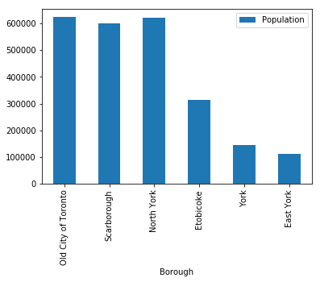

```python
dd_agg.plot.bar(x= "Borough", y= "Population")
```

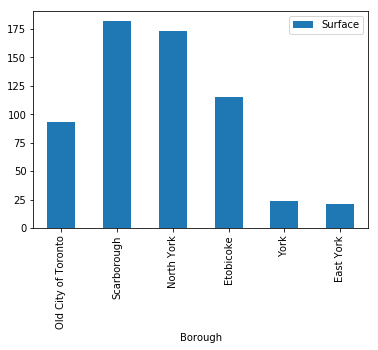

```python
dd_agg.plot.bar(x= "Borough", y= "Surface")
```

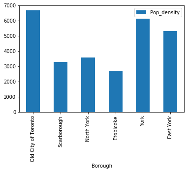

```python
dd_agg.plot.bar(x= "Borough", y= "Pop_density")
```

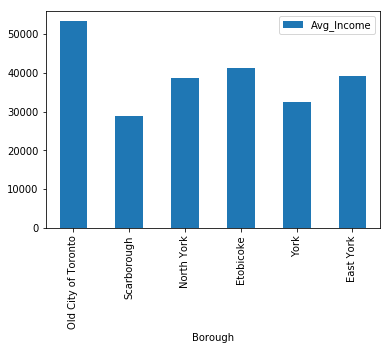

```python
dd_agg.plot.bar(x= "Borough", y= "Avg_Income")
```

Go on top

## Disscusion

- Given the fact that I am looking to optimize the location of a national restaurant, I will continue to focus more on the demographic aspect of the city of Toronto
- I am encouraged in this direction by the fact that the results from the k-mean clustering model are quite evasive and inconclusive.
- I found a file in Wikipedia that includes information about the population, average income, area, second language spoken after English, etc. The file gives all these info for the Toronto city and its borough and neighborhood
- The file is called "Demographics_of_Toronto_neighbourhoods"
- The file has been downloaded into a pandas dataframe, clean out, etc.
- It has been processed so that the meaningful data can be visualized and analyzed.

Go on top

Go on top

## Conclusion

- After examining the demographic data, it can be seen that "Old Toronto" is the city borough with the highest population but also, with the highest population density
- In terms of average earnings Old Toronto is again in first place with an average of 53407 dollars
- After than come Etobicoke with 41251 and East York with 39186 dollars.
- The last ones are North York with 38537, York with 32431 and at last Scarborough with 28806 dollars
- From the above mentioned file I didn't get any information regarding the Romanian community in Toronto.
- I searched the internet and I found out that in Toronto are only 30,000 Romanians.
- No any information on how they are spread in the city was found.
- Consequently, I looked for information on Eastern or Southeast European populations that may become future customers.
- I found out that in Old Toronto and East York there are 11 respective 21 neighborhoods where the population has a east or south east native European language.
- The only Romanian restaurant in Toronto, 'Moldova', is located in East York and is a 3.5 star restaurant under Russian management
- From their list of remarks I noticed that people with Romanian names leave an unsatisfactory message like 'I didn't find what I expected', the other people leave good or very good messages.
- I conclude from here that there is still a requirement of an authentic Romanian restaurant.

Go on top